#### Marijuana, Alcohol, and Other Drugs

**Continuing our Exploration of the Data** Having discovered the sources of crime growth, it’s time to look at something which interests many people in the US - what short-term impact has Denver seen since the legalization of marijuana. This is going to be a *very* simplistic view because it will only focus on trend data (which never tells the whole story). However, it’s interesting to look at!

**What we’ll do in this post**

- All data was loaded, formatted, and prepared in [Part 1](http://stoltzmaniac.com/crime-analysis-denver-part-1/)
- Look into crimes related to drugs and alcohol
- We’ll focus only on those that are classified as OFFENSE_CATEGORY_ID “drug-alcohol”
- In comparing Year-over-Year data, partial months will be excluded

Let’s dive in!

**Exploration of Data**  
Data provided by http://data.denvergov.org

**Looking Into Drugs and Alcohol**

- First - what are the top 15 crimes types (as defined by CRIME_TYPE_ID)?
- Second - how have the number of incidents reported changed over the last 3 years?

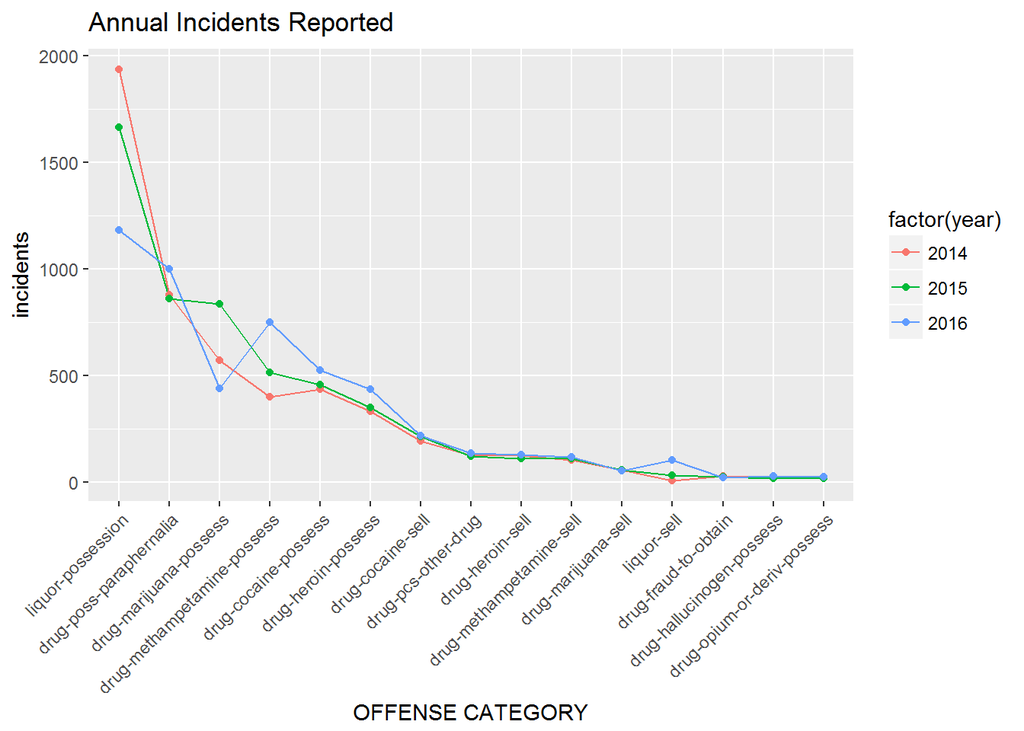

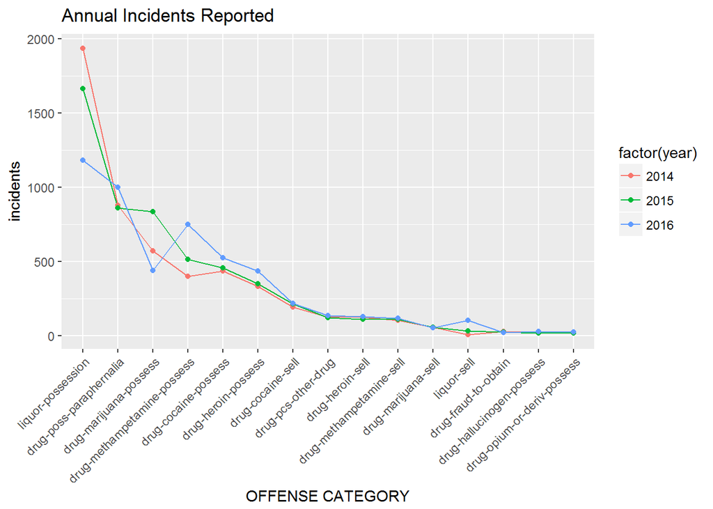

```r
topCrimes = data %>%
  filter(OFFENSE_CATEGORY_ID == 'drug-alcohol') %>%
  filter(year >= 2014) %>%
  filter(month < maxMonthYTD) %>%
  group_by(OFFENSE_TYPE_ID) %>%
  summarise(incidents = sum(incidents)) %>%
  arrange(desc(incidents))
topCrimes = topCrimes$OFFENSE_TYPE_ID[1:15]

df = data %>%
  filter(OFFENSE_CATEGORY_ID == 'drug-alcohol') %>%
  filter(OFFENSE_TYPE_ID %in% topCrimes) %>%
  filter(year >= 2014) %>%
  filter(month < maxMonthYTD) %>%
  group_by(OFFENSE_TYPE_ID,year) %>%
  summarise(incidents = sum(incidents))

p = ggplot(df,aes(x=reorder(OFFENSE_TYPE_ID,-incidents),y=incidents,group=factor(year),col=factor(year)))
p + geom_line() + geom_point() + theme(axis.text.x = element_text(angle = 45,hjust=1)) + ggtitle(paste("Annual Incidents Reported")) + labs(x = "OFFENSE CATEGORY")
```

**Observations**

- Liquor posession is the highest of drug-alcohol violations
- Marijuana ranks third, just after possession of drug parphenalia
- Methampetamines break the pattern of decline - it actually grew from 2014-2016
- Cocaine and Heroin posession also grew over the period, but at a much smaller volume than methampetamines

**Marijuana Approved for Recreational Usage**

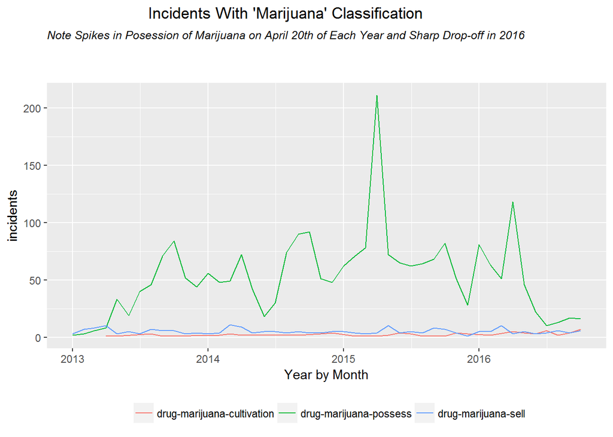

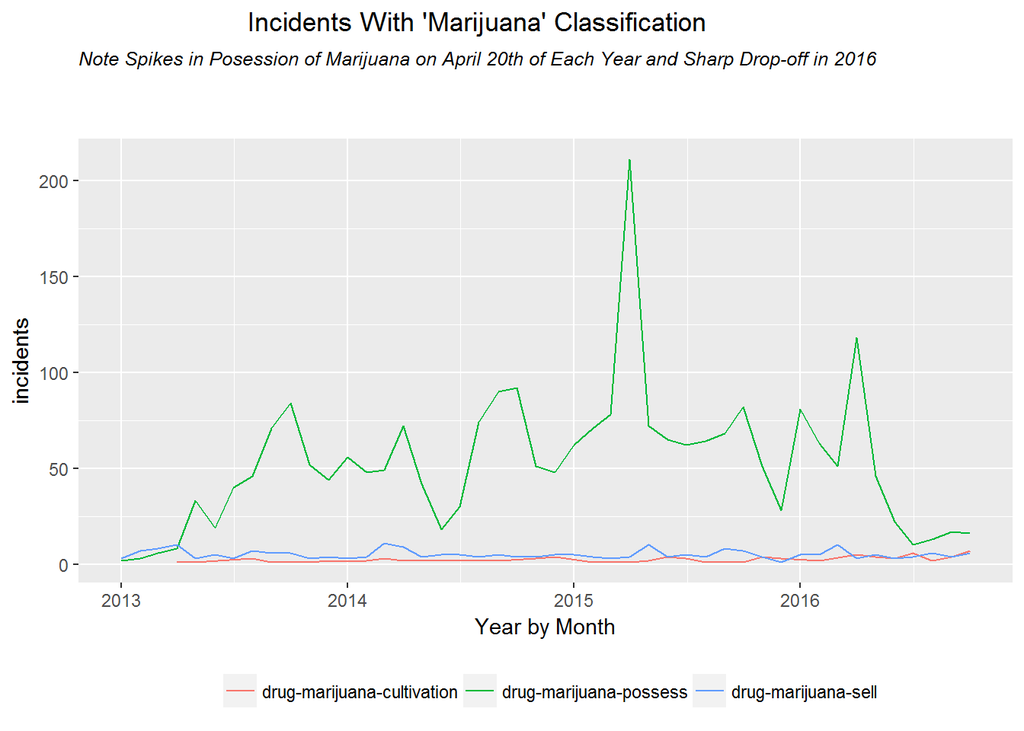

barplotCrime

```r
df = data %>%
  filter(date <= '2016-10-31') %>%
  filter(year >= 2013) %>%
  filter(grepl('marijuana',OFFENSE_TYPE_ID)) %>%
  group_by(OFFENSE_TYPE_ID,year,month) %>%
  summarise(incidents = sum(incidents))
df$yearMonth = as.Date(paste(as.character(df$year),"-",as.character(df$month),"-01",sep=''))
p = ggplot(df,aes(x=yearMonth,y=incidents,col=OFFENSE_TYPE_ID,fill=OFFENSE_TYPE_ID))
p + geom_line() + theme(legend.position = 'bottom',legend.title=element_blank()) + ggtitle(expression(atop(paste("Incidents With 'Marijuana' Classification"),atop(italic('Note Spikes in Posession of Marijuana on April 20th of Each Year and Sharp Drop-off in 2016'),"")))) + labs(x='Year by Month')
```

**Observations**

- It looks like the middle of 2016 showed a dramatic decrease in incidents
- Possession incidents were a much larger percentage of the violations until the middle of 2016
- The sudden decrease in incidents has a strange timing - I believe marijuana was legalized in Colorado in 2014 (perhaps I’m wrong on this) - so it would actually make more sense if the drop off had occurred when it was implemented
- It appears as if I was relatively close on the timing [Wikipedia Article](https://en.wikipedia.org/wiki/Cannabis_in_Colorado)
- I may be missing something here - it’s important to note that this has nothing to do with sentencing and is only what is reported to the police
- Apparently April 20th (aka 420) is a big deal in the marijuana world
- Wikipedia Article

**What % Changes Occurred**

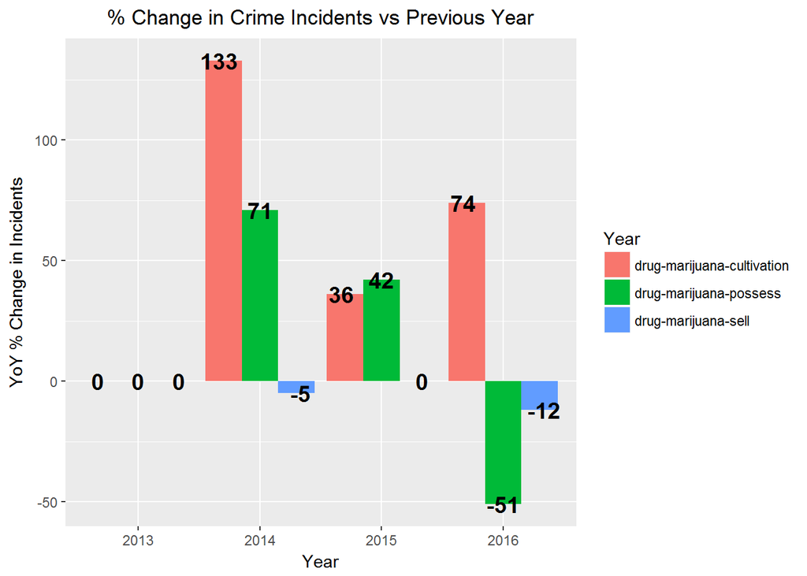

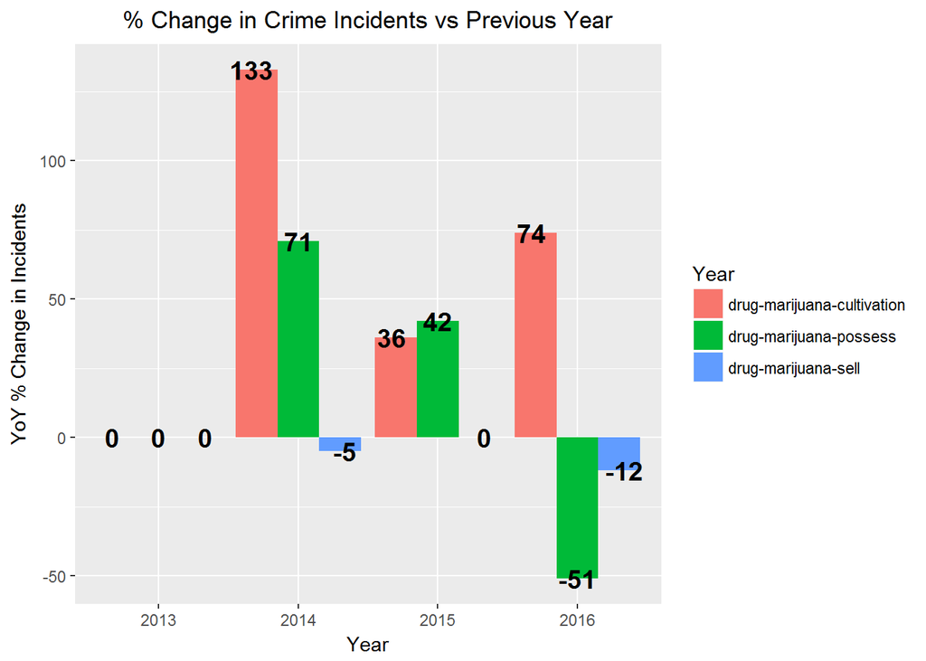

barplotCrime

```r
df2 = data %>%
  filter(date <= '2016-10-31') %>%
  filter(year >= 2013) %>%
  filter(month <= maxMonthYTD) %>%
  filter(grepl('marijuana',OFFENSE_TYPE_ID)) %>%
  group_by(OFFENSE_TYPE_ID,year) %>%
  summarise(incidents = sum(incidents)) %>%
  arrange(OFFENSE_TYPE_ID,year) %>%
  mutate(year,YoYchange=round(100*((incidents-lag(incidents))/lag(incidents))),0)
df2[is.na(df2)] = 0
p = ggplot(df2,aes(x=factor(year),y=YoYchange,group=OFFENSE_TYPE_ID,fill=OFFENSE_TYPE_ID,label=YoYchange))
p + geom_bar(stat='identity',position='dodge') + ggtitle('% Change in Crime Incidents vs Previous Year') + xlab('Year') + ylab('YoY % Change in Incidents') + theme(plot.title = element_text(hjust = 0.5)) + guides(fill = guide_legend(title='Year')) + geom_text(position = position_dodge(width=1),col='black',size=5,fontface='bold')
```

**Observations**

- Marijuana cultivation grew each year
- Posession dropped by 51% from 2015 to 2016 (holding months constant)
- The incidents of crimes regarding selling decreased
- This seems to make sense - if there are legal channels, it would make sense to take advantage of them as long as the financial incentives are in place as well

**Taking a Sip of Liquor**

*Liquor ranked as #1 in the “drug-alcohol” Category*

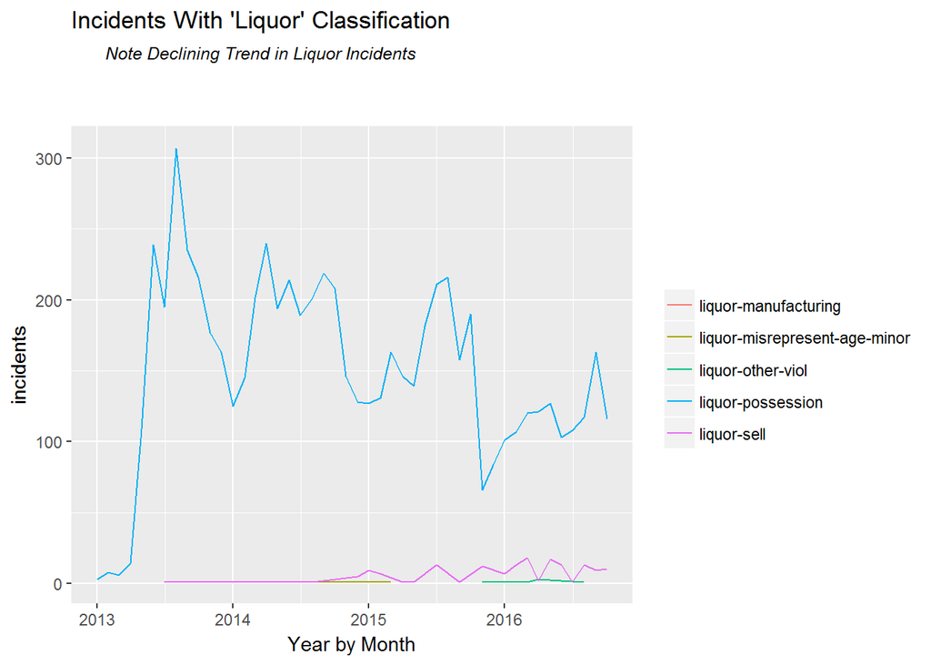

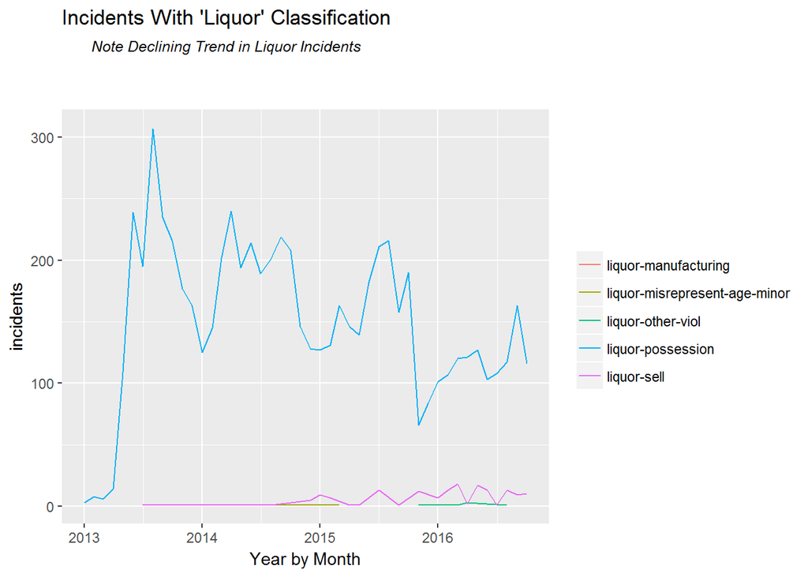

barplotCrime

```r
df = data %>%
  filter(date <= '2016-10-31') %>%
  filter(year >= 2013) %>%
  filter(grepl('alcohol|liquor',OFFENSE_TYPE_ID)) %>%
  group_by(OFFENSE_TYPE_ID,year,month) %>%
  summarise(incidents = sum(incidents))
df$yearMonth = as.Date(paste(as.character(df$year),"-",as.character(df$month),"-01",sep=''))
p = ggplot(df,aes(x=yearMonth,y=incidents,col=OFFENSE_TYPE_ID,fill=OFFENSE_TYPE_ID))
p + geom_line() + theme(legend.position = 'right',legend.title=element_blank()) + ggtitle(expression(atop(paste("Incidents With 'Liquor' Classification"),atop(italic('Note Declining Trend in Liquor Incidents'),"")))) + labs(x='Year by Month')
```

**Observations**

- Liquor posession dominates the number of incidents
- With liquor manufacturing so low, it appears as if bootleggers and moonshiners probably don’t thrive in Colorado
- Appears as if ther’es a downward trend in the number of incidents each year

**What About Methamphetamine?**

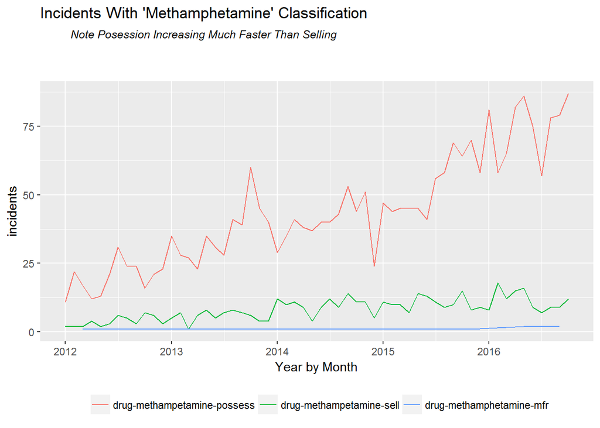

[figure not shown]

barplotCrime

```r
df = data %>%
  filter(date <= '2016-10-31') %>%
  filter(year >= 2012) %>%
  filter(grepl('methamphetamine|methampetamine',OFFENSE_TYPE_ID)) %>%
  group_by(OFFENSE_TYPE_ID,year,month) %>%
  summarise(incidents = sum(incidents))
df$yearMonth = as.Date(paste(as.character(df$year),"-",as.character(df$month),"-01",sep=''))
p = ggplot(df,aes(x=yearMonth,y=incidents,col=OFFENSE_TYPE_ID,fill=OFFENSE_TYPE_ID))
p + geom_line() + theme(legend.position = 'bottom',legend.title=element_blank()) + ggtitle(expression(atop(paste("Incidents With 'Methamphetamine' Classification"),atop(italic('Note Posession Increasing Much Faster Than Selling'),"")))) + labs(x='Year by Month')
```

**Observations**

- There is a very rapid growth in methampetamine incidents
- Very steady growth since 2012 - hopefully this declines moving forward

**Growth % for Methamphetamines**

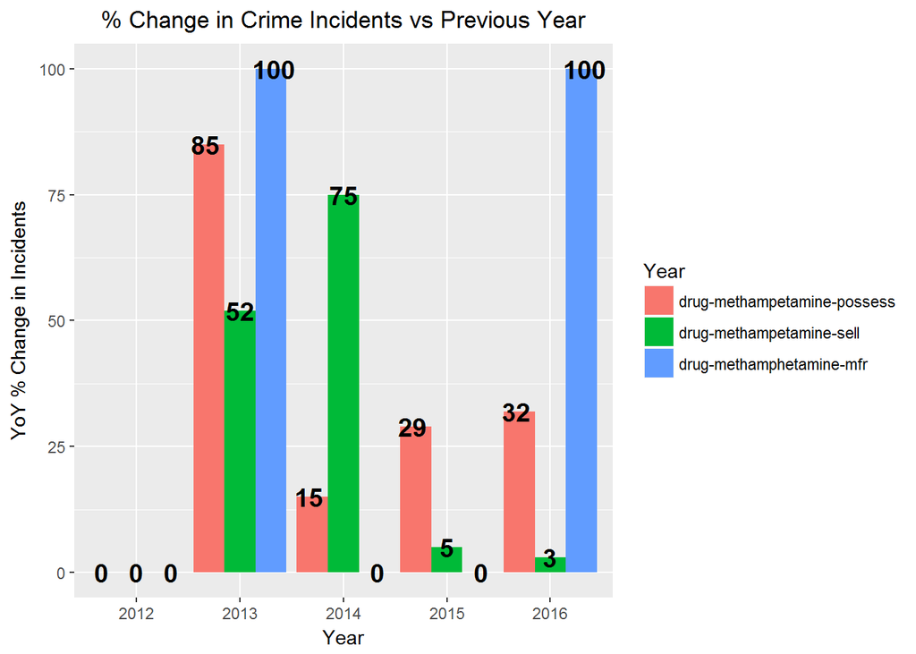

[figure not shown]

barplotCrime

```r
df2 = data %>%
  filter(year >= 2012) %>%
  filter(month <= maxMonthYTD) %>%
  filter(grepl('methamphetamine|methampetamine',OFFENSE_TYPE_ID)) %>%
  group_by(OFFENSE_TYPE_ID,year) %>%
  summarise(incidents = sum(incidents)) %>%
  arrange(OFFENSE_TYPE_ID,year) %>%
  mutate(year,YoYchange=round(100*((incidents-lag(incidents))/lag(incidents))),0)
df2[is.na(df2)] = 0
p = ggplot(df2,aes(x=factor(year),y=YoYchange,group=OFFENSE_TYPE_ID,fill=OFFENSE_TYPE_ID,label=YoYchange))
p + geom_bar(stat='identity',position='dodge') + ggtitle('% Change in Crime Incidents vs Previous Year') + xlab('Year') + ylab('YoY % Change in Incidents') + theme(plot.title = element_text(hjust = 0.5)) + guides(fill = guide_legend(title='Year')) + geom_text(position = position_dodge(width=1),col='black',size=5,fontface='bold')
```

**Observations**

- Large percentage growth still occurs in posession but not sales crimes
- When did Breaking Bad end? Perhaps this is more than a coincidence…

**Final Thoughts (for now)**

The population of Denver has been increasing at a large rate for the last decade or so. None of this data has been population adjusted which could be painting the wrong picture. However, it’s interesting to notice alcohol and marijuana incidents on the decline with methamphetamine and heroin incidents increasing. According to what I remember from D.A.R.E., meth and heroin are pretty nasty drugs, which is slightly worrisome. However, issues with liquor and alcohol still rank #1 for now.

Colorado has been known for large growth in the microbrewery industry and now recreational marijuana dispensaries as well. The crime data seems to indicate a downward trend in both alcohol and marijuana, perhaps there is a negative correlation between crime incidents and business openings in those industries.

**What I’ll do in the next crime posts**

- Look for patterns by location
- Lay out some visualizations on maps

*Feel free to comment and perhaps you can take some of this data and run with some ideas of your own!*

My code for this is posted on GitHub:  
https://github.com/stoltzmaniac/Denver-Crime-Analysis.git